# ACV_Project2_Part1_FaceIdentificationModel

```python
import numpy as np
import pandas as pd
import matplotlib.pyplot as plt
%matplotlib inline

from sklearn.metrics import accuracy_score

import tensorflow
tensorflow.__version__
```

```
'2.6.0'
```

```python
import sys
import numpy as np
import pickle
import os
import matplotlib.pyplot as plt
%matplotlib inline

import cv2
import time
import itertools
import random

from sklearn.utils import shuffle
import tensorflow as tf

from tensorflow.keras.models import Sequential
from tensorflow.keras.optimizers import Adam, RMSprop
from tensorflow.keras.layers import Conv2D, ZeroPadding2D, Activation, Input, concatenate, Dropout
from tensorflow.keras.models import Model

from tensorflow.keras.layers import BatchNormalization
from tensorflow.keras.layers import MaxPooling2D
from tensorflow.keras.layers import Concatenate
from tensorflow.keras.layers import Lambda, Flatten, Dense

from tensorflow.keras.layers import Layer
from tensorflow.keras.regularizers import l2
from tensorflow.keras import backend as K
from tensorflow.keras.callbacks import EarlyStopping, ModelCheckpoint, ReduceLROnPlateau
```

## Step 1- Load the dataset and create the metadata.

```python
from google.colab import drive

drive.mount('/content/drive/')
```

```python
project_path = "/content/drive/MyDrive/DLCP/CNN/AdvCNN/Project2/ACV Project 2 Dataset.zip"
```

# Extract the zip file

```python
!ls
```

```
drive  sample_data
```

```python
from zipfile import ZipFile

with ZipFile(project_path,'r') as z:
  z.extractall()
```

```python
!ls
```

```
'ACV Project 2 Dataset'   drive   sample_data
```

```python
#path="./ACV Project 2 Dataset/Dataset Aligned Face Dataset from Pinterest/PINS/"
path="./ACV Project 2 Dataset/Dataset Aligned Face Dataset from Pinterest/"
```

```python
!ls
```

```
'ACV Project 2 Dataset'   drive   sample_data
```

```python
os.listdir(path)
```

```
['PINS']
```

```python
# Get the list of all directories and sort them
dir_list = next(os.walk(path))[1]
dir_list.sort()
```

```python
dir_list
```

```
['pins_Aaron Paul',
 'pins_Alvaro Morte',
 'pins_Amanda Crew',
 'pins_Amaury Nolasco',
 'pins_Anna Gunn',
 'pins_Benedict Cumberbatch',
 'pins_Betsy Brandt',
 'pins_Brenton Thwaites',
 'pins_Brit Marling',
 'pins_Bryan Cranston',
 'pins_Caity Lotz',
 'pins_Cameron Monaghan',
 'pins_Chance Perdomo',
 'pins_Chris Evans',
 'pins_Chris Pratt',
 'pins_Cobie Smulders',
 'pins_Danielle Panabaker',
 'pins_Dave Franco',
 'pins_Dominic Purcell',
 'pins_Dwayne Johnson',
 'pins_Emilia Clarke',
 'pins_Emily Bett Rickards',
 'pins_Emma Stone',
 'pins_Gwyneth Paltrow',
 'pins_Henry Cavil',
 'pins_Jason Momoa',
 'pins_Jeremy Renner',
 'pins_Jesse Eisenberg',
 'pins_Jim Parsons',
 'pins_Jon Bernthal',
 'pins_Josh Radnor',
 'pins_Kit Harington',
 'pins_Krysten Ritter',
 'pins_Kumail Nanjiani',
 'pins_Maisie Williams',
 'pins_Mark Ruffalo',
 'pins_Martin Starr',
 'pins_Melissa benoit',
 'pins_Mike Colter',
 'pins_Morena Baccarin',
```

[output cut: 45 more lines]

```
 'pins_lindsey morgan face',
 'pins_margot robbie face',
 'pins_maria pedraza',
 'pins_mark zuckerberg',
 'pins_miguel herran',
 'pins_millie bobby brown',
 'pins_rihanna',
 'pins_robert downey jr face',
 'pins_sean pertwee',
 'pins_selena gomez',
 'pins_shakira',
 'pins_tati gabrielle',
 'pins_taylor swift',
 'pins_tom holland face',
 'pins_zendaya']
```

```python
len(dir_list)
```

```
100
```

# Function to load images

Define a function to load the images from the extracted folder and map each image with person id

```python
import numpy as np
import os

class IdentityMetadata():
    def __init__(self, base, name, file):
        # print(base, name, file)
        # dataset base directory
        self.base = base
        # identity name
        self.name = name
        # image file name
        self.file = file

    def __repr__(self):
        return self.image_path()

    def image_path(self):
        return os.path.join(self.base, self.name, self.file)

def load_metadata(path):
    metadata = []
    for i in os.listdir(path):
        for f in os.listdir(os.path.join(path, i)):
            # Check file extension. Allow only jpg/jpeg' files.
            ext = os.path.splitext(f)[1]
            if ext == '.jpg' or ext == '.jpeg':
                metadata.append(IdentityMetadata(path, i, f))
    return np.array(metadata)
```

```python
# metadata = load_metadata('images')
metadata = load_metadata('./ACV Project 2 Dataset/Dataset Aligned Face Dataset from Pinterest/PINS/')
```

# Define function to load image

Define a function to load image from the metadata

```python
import cv2
def load_image(path):
    img = cv2.imread(path, 1)
    # OpenCV loads images with color channels
    # in BGR order. So we need to reverse them
    return img[...,::-1]
```

# Load a sample image

Load one image using the function "load_image"

[output not shown]

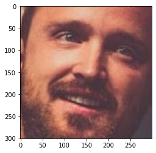

```python
sample=load_image('./ACV Project 2 Dataset/Dataset Aligned Face Dataset from Pinterest/PINS/pins_Aaron Paul/Aaron Paul0_262.jpg')
print(sample)
plt.imshow(sample)
```

# Preparing y_train (labels)

```python
Labels=[]
for i in range (len(dir_list)):
  temp=dir_list[i]
  name=temp.split('_')
  lab=name[-1]
  Labels.append(lab)
print(Labels)
```

```
['Aaron Paul', 'Alvaro Morte', 'Amanda Crew', 'Amaury Nolasco', 'Anna Gunn', 'Benedict Cumberbatch', 'Betsy Brandt', 'Brenton Thwaites', 'Brit Marling', 'Bryan Cranston', 'Caity Lotz', 'Cameron Monaghan', 'Chance Perdomo', 'Chris Evans', 'Chris Pratt', 'Cobie Smulders', 'Danielle Panabaker', 'Dave F…
```

```python
y_train=[]
i=0
for i in range(len(dir_list)):
  images=os.listdir(path+dir_list[i])
  for img in images:
    y_train.append(i)
  i=i+1
```

```python
len(y_train)
```

```
10770
```

```python
np.unique(y_train)
```

```
array([ 0,  1,  2,  3,  4,  5,  6,  7,  8,  9, 10, 11, 12, 13, 14, 15, 16,
       17, 18, 19, 20, 21, 22, 23, 24, 25, 26, 27, 28, 29, 30, 31, 32, 33,
       34, 35, 36, 37, 38, 39, 40, 41, 42, 43, 44, 45, 46, 47, 48, 49, 50,
       51, 52, 53, 54, 55, 56, 57, 58, 59, 60, 61, 62, 63, 64, 65, 66, 67,
       68, 69, 70, 71, 72, 73, 74, 75, 76, 77, 78, 79, 80, 81, 82, 83, 84,
       85, 86, 87, 88, 89, 90, 91, 92, 93, 94, 95, 96, 97, 98, 99])
```

# Preparing x_train

```python
import numpy as np
import matplotlib.pyplot as plt
import cv2

x_train=[]
for i in range(len(dir_list)):
  images=os.listdir(path+dir_list[i])
  for ii in images:
    image = cv2.imread(path+dir_list[i]+'/'+ii)
    x_train.append(image)
```

```python
len(x_train),len(y_train)
```

```
(10770, 10770)
```

# Step 2- Check some samples of metadata.

```python
print(Labels)
```

```
['Aaron Paul', 'Alvaro Morte', 'Amanda Crew', 'Amaury Nolasco', 'Anna Gunn', 'Benedict Cumberbatch', 'Betsy Brandt', 'Brenton Thwaites', 'Brit Marling', 'Bryan Cranston', 'Caity Lotz', 'Cameron Monaghan', 'Chance Perdomo', 'Chris Evans', 'Chris Pratt', 'Cobie Smulders', 'Danielle Panabaker', 'Dave F…
```

```
Image belongs to: Aaron Paul
```

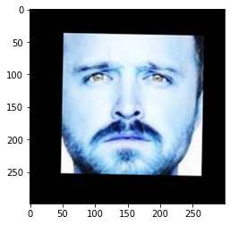

```python
plt.imshow(x_train[45]);
print("Image belongs to:",Labels[y_train[45]])
```

```
Image belongs to: Anna Gunn
```

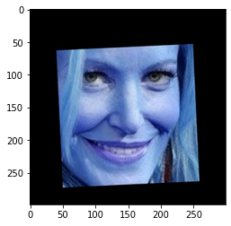

```python
plt.imshow(x_train[450]);
print("Image belongs to:",Labels[y_train[450]])
```

```
Image belongs to: Neil Patrick Harris
```

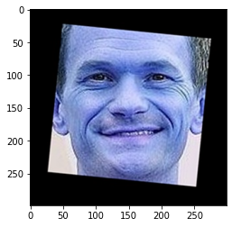

```python
plt.imshow(x_train[4500]);
print("Image belongs to:",Labels[y_train[4500]])
```

```
Image belongs to: rihanna
```

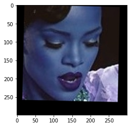

```python
plt.imshow(x_train[10000]);
print("Image belongs to:",Labels[y_train[10000]])
```

## Step 3- Load the pre-trained model and weights

# VGG Face model

```python
from tensorflow.keras.models import Sequential
from tensorflow.keras.layers import ZeroPadding2D, Convolution2D, MaxPooling2D, Dropout, Flatten, Activation

def vgg_face():
    model = Sequential()
    model.add(ZeroPadding2D((1,1),input_shape=(224,224, 3)))
    model.add(Convolution2D(64, (3, 3), activation='relu'))
    model.add(ZeroPadding2D((1,1)))
    model.add(Convolution2D(64, (3, 3), activation='relu'))
    model.add(MaxPooling2D((2,2), strides=(2,2)))

    model.add(ZeroPadding2D((1,1)))
    model.add(Convolution2D(128, (3, 3), activation='relu'))
    model.add(ZeroPadding2D((1,1)))
    model.add(Convolution2D(128, (3, 3), activation='relu'))
    model.add(MaxPooling2D((2,2), strides=(2,2)))

    model.add(ZeroPadding2D((1,1)))
    model.add(Convolution2D(256, (3, 3), activation='relu'))
    model.add(ZeroPadding2D((1,1)))
    model.add(Convolution2D(256, (3, 3), activation='relu'))
    model.add(ZeroPadding2D((1,1)))
    model.add(Convolution2D(256, (3, 3), activation='relu'))
    model.add(MaxPooling2D((2,2), strides=(2,2)))

    model.add(ZeroPadding2D((1,1)))
    model.add(Convolution2D(512, (3, 3), activation='relu'))
    model.add(ZeroPadding2D((1,1)))
    model.add(Convolution2D(512, (3, 3), activation='relu'))
    model.add(ZeroPadding2D((1,1)))
    model.add(Convolution2D(512, (3, 3), activation='relu'))
    model.add(MaxPooling2D((2,2), strides=(2,2)))

    model.add(ZeroPadding2D((1,1)))
    model.add(Convolution2D(512, (3, 3), activation='relu'))
    model.add(ZeroPadding2D((1,1)))
    model.add(Convolution2D(512, (3, 3), activation='relu'))
    model.add(ZeroPadding2D((1,1)))
    model.add(Convolution2D(512, (3, 3), activation='relu'))
    model.add(MaxPooling2D((2,2), strides=(2,2)))

    model.add(Convolution2D(4096, (7, 7), activation='relu'))
    model.add(Dropout(0.5))
    model.add(Convolution2D(4096, (1, 1), activation='relu'))
    model.add(Dropout(0.5))
    model.add(Convolution2D(2622, (1, 1)))
    model.add(Flatten())
    model.add(Activation('softmax'))
    return model
```

# Load the model

Load the model defined above

Then load the pre-trained weight file named "vgg_face_weights.h5"

```python
model = vgg_face()
model.load_weights('/content/drive/MyDrive/DLCP/CNN/AdvCNN/Project2/vgg_face_weights.h5')
```

# Get vgg_face_descriptor

```python
from tensorflow.keras.models import Model
vgg_face_descriptor = Model(inputs=model.layers[0].input, outputs=model.layers[-2].output)
```

# Step 4 - Generate Embedding vectors for each face in the dataset

Below is a sample to load the first image in the metadata and get its embedding vector from the pre-trained model.

```python
# Get embedding vector for first image in the metadata using the pre-trained model

img_path = metadata[0].image_path()
img = load_image(img_path)

# Normalising pixel values from [0-255] to [0-1]: scale RGB values to interval [0,1]
img = (img / 255.).astype(np.float32)

img = cv2.resize(img, dsize = (224,224))
print(img.shape)

# Obtain embedding vector for an image
# Get the embedding vector for the above image using vgg_face_descriptor model and print the shape

embedding_vector = vgg_face_descriptor.predict(np.expand_dims(img, axis=0))[0]
print(embedding_vector.shape)
```

```
(224, 224, 3)
(2622,)
```

# Generate Embedding vectors for each face in the dataset

The below code is to iterate through metadata and create embeddings for each image using vgg_face_descriptor.predict() and store in a list with name embeddings

If there is any error in reading any image in the dataset, we will fill the emebdding vector of that image with 2622-zeroes as the final embedding from the model is of length 2622.

```python
embeddings = np.zeros((metadata.shape[0], 2622))

for i, m in enumerate(metadata):
  img_path  = m.image_path()
  img       = load_image(img_path)

  # Normalising pixel values from [0-255] to [0-1]: scale RGB values to interval [0,1]
  img = (img / 255.).astype(np.float32)
  img = cv2.resize(img, dsize = (224,224))

  # Obtain embedding vector for an image
  # Get the embedding vector for the above image using vgg_face_descriptor model
  embeddings[i]= vgg_face_descriptor.predict(np.expand_dims(img, axis=0))[0]
```

# Step 5: Function to calculate distance between given 2 pairs of images.

Consider distance metric as "Squared L2 distance"

Squared l2 distance between 2 points (x1, y1) and (x2, y2) = (x1-x2)^2 + (y1-y2)^2

```python
def distance(emb1, emb2):
    return np.sum(np.square(emb1 - emb2))
```

# Plotting images and get distance between the pairs given below

2, 3 and 2, 180

30, 31 and 30, 100

70, 72 and 70, 115

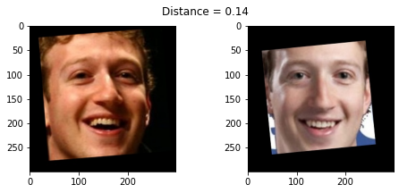

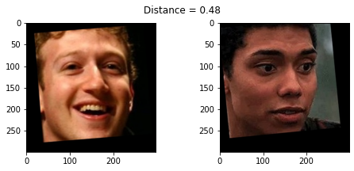

```python
import matplotlib.pyplot as plt

def show_pair(idx1, idx2):
    plt.figure(figsize=(8,3))
    plt.suptitle(f'Distance = {distance(embeddings[idx1], embeddings[idx2]):.2f}')
    plt.subplot(121)
    plt.imshow(load_image(metadata[idx1].image_path()))
    plt.subplot(122)
    plt.imshow(load_image(metadata[idx2].image_path()));

show_pair(2, 3)
show_pair(2, 180)
```

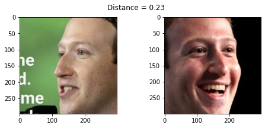

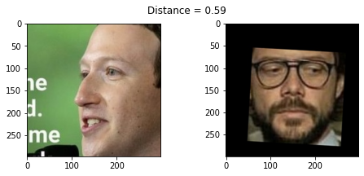

```python
show_pair(30, 31)
show_pair(30, 100)
```

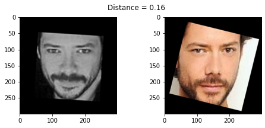

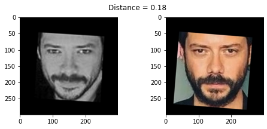

```python
show_pair(70,72)
show_pair(70,115)
```

# Create train and test sets

Create X_train, X_test and y_train, y_test

Use train_idx to seperate out training features and labels

Use test_idx to seperate out testing features and labels

```python
train_idx = np.arange(metadata.shape[0]) % 9 != 0     #every 9th example goes in test data and rest go in train data
test_idx = np.arange(metadata.shape[0]) % 9 == 0

# one half as train examples of 10 identities
X_train = embeddings[train_idx]

# another half as test examples of 10 identities
X_test = embeddings[test_idx]

targets = np.array([m.name for m in metadata])
#train labels
y_train = targets[train_idx]
#test labels
y_test = targets[test_idx]
```

# Encode the Labels

Encode the targets

Use LabelEncoder

```python
from sklearn.preprocessing import LabelEncoder

labencodr = LabelEncoder()
ytrain    = labencodr.fit_transform(y_train)
ytest     = labencodr.transform(y_test)
```

# Standardize the feature values

Scale the features using StandardScaler

```python
# Standarize features
from sklearn.preprocessing import StandardScaler

standscaler   = StandardScaler()
Xtrain_scaled = standscaler.fit_transform(X_train)
Xtest_scaled  = standscaler.transform(X_test)
```

# Step 6: Reduce dimensions using PCA

Reduce feature dimensions using Principal Component Analysis

Set the parameter n_components=128

```python
from sklearn.decomposition import PCA

pca               = PCA(n_components=128)
Xtrain_transfrmd  = pca.fit_transform(Xtrain_scaled)
Xtest_transfrmd   = pca.transform(Xtest_scaled)
```

# Step 7:Build an SVM classifier to map each image to its right person.

```python
from sklearn.svm import SVC

model = SVC()
model.fit(Xtrain_transfrmd,ytrain)
print("Training Score is: ",model.score(Xtrain_transfrmd,ytrain))
print("Testing Score is: ",accuracy_score(model.predict(Xtest_transfrmd),ytest))
```

```
Training Score is:  0.9963438838399665
Testing Score is:  0.9649122807017544
```

```python
y_predict = clf.predict(X_test_pca)
```

# Step 8 : Test results : Predict using the SVM model.

Report to which person(folder name in dataset) the image belongs to

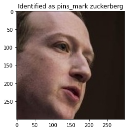

```python
import warnings
# Suppress LabelEncoder warning
warnings.filterwarnings('ignore')

example_idx = 10

example_image = load_image(metadata[example_idx].image_path())

# Normalising pixel values from [0-255] to [0-1]: scale RGB values to interval [0,1]
img = (example_image / 255.).astype(np.float32)
img = cv2.resize(img, dsize = (224,224))

# Get the embedding vector for the above image using vgg_face_descriptor model
embedding_vector = vgg_face_descriptor.predict(np.expand_dims(img, axis=0))[0]

example_image_scaled = standscaler.transform(embeddings)

example_image_pca = pca.transform(example_image_scaled)

example_prediction = model.predict(example_image_pca)

example_identity = labencodr.inverse_transform(example_prediction)[0]

plt.imshow(example_image)
plt.title(f'Identified as {example_identity}');
```

## Conclusion

Generated embeddings for all images using pre-trained VGG Face model.

Used "Squared L2 distance" to calculate the distance between given 2 pairs of images.

Encoded the target variables, standardize the features and reduced dimensions using PCA.